# matplotlib.axes.Axes.errorbar

**Axes.errorbar(*x*, *y*, *yerr=None*, *xerr=None*, *fmt=''*, *, *ecolor=None*, *elinewidth=None*, *capsize=None*, *barsabove=False*, *lolims=False*, *uplims=False*, *xlolims=False*, *xuplims=False*, *errorevery=1*, *capthick=None*, *data=None*, **kwargs)[[source]](https://github.com/matplotlib/matplotlib/blob/v3.10.8/lib/matplotlib/axes/_axes.py#L3515-L3894)**

Plot y versus x as lines and/or markers with attached errorbars.

*x*, *y* define the data locations, *xerr*, *yerr* define the errorbar sizes. By default, this draws the data markers/lines as well as the errorbars. Use fmt='none' to draw errorbars without any data markers.

Added in version 3.7: Caps and error lines are drawn in polar coordinates on polar plots.

**Parameters:**

**x, y**float or array-like**

The data positions.

**xerr, yerr**float or array-like, shape(N,) or shape(2, N), optional**

The errorbar sizes:

- scalar: Symmetric +/- values for all data points.
- shape(N,): Symmetric +/-values for each data point.
- shape(2, N): Separate - and + values for each bar. First row contains the lower errors, the second row contains the upper errors.
- *None*: No errorbar.

All values must be >= 0.

See [Different ways of specifying error bars](https://matplotlib.org/stable/gallery/statistics/errorbar_features.html) for an example on the usage of `xerr` and `yerr`.

**fmt**str, default: ''**

The format for the data points / data lines. See `plot` for details.

Use 'none' (case-insensitive) to plot errorbars without any data markers.

**ecolor**[color](https://matplotlib.org/stable/users/explain/colors/colors.html#colors-def), default: None**

The color of the errorbar lines. If None, use the color of the line connecting the markers.

**elinewidth**float, default: None**

The linewidth of the errorbar lines. If None, the linewidth of the current style is used.

**capsize**float, default: `rcParams["errorbar.capsize"]` (default: `0.0`)**

The length of the error bar caps in points.

**capthick**float, default: None**

An alias to the keyword argument *markeredgewidth* (a.k.a. *mew*). This setting is a more sensible name for the property that controls the thickness of the error bar cap in points. For backwards compatibility, if *mew* or *markeredgewidth* are given, then they will over-ride *capthick*. This may change in future releases.

**barsabove**bool, default: False**

If True, will plot the errorbars above the plot symbols. Default is below.

**lolims, uplims, xlolims, xuplims**bool or array-like, default: False**

These arguments can be used to indicate that a value gives only upper/lower limits. In that case a caret symbol is used to indicate this. *lims*-arguments may be scalars, or array-likes of the same length as *xerr* and *yerr*. To use limits with inverted axes, `set_xlim` or `set_ylim` must be called before `errorbar()`. Note the tricky parameter names: setting e.g. *lolims* to True means that the y-value is a *lower* limit of the True value, so, only an *upward*-pointing arrow will be drawn!

**errorevery**int or (int, int), default: 1**

draws error bars on a subset of the data. *errorevery* =N draws error bars on the points (x[::N], y[::N]). *errorevery* =(start, N) draws error bars on the points (x[start::N], y[start::N]). e.g. errorevery=(6, 3) adds error bars to the data at (x[6], x[9], x[12], x[15], ...). Used to avoid overlapping error bars when two series share x-axis values.

**Returns:**

**`ErrorbarContainer`**

The container contains:

- data_line : A `Line2D` instance of x, y plot markers and/or line.
- caplines : A tuple of `Line2D` instances of the error bar caps.
- barlinecols : A tuple of `LineCollection` with the horizontal and vertical error ranges.

**Other Parameters:**

**data**indexable object, optional**

If given, the following parameters also accept a string `s`, which is interpreted as `data[s]` if `s` is a key in `data`:

*x*, *y*, *xerr*, *yerr*

**kwargs**

All other keyword arguments are passed on to the `plot` call drawing the markers. For example, this code makes big red squares with thick green edges:

```
x, y, yerr = rand(3, 10)
errorbar(x, y, yerr, marker='s', mfc='red',
         mec='green', ms=20, mew=4)
```

where *mfc*, *mec*, *ms* and *mew* are aliases for the longer property names, *markerfacecolor*, *markeredgecolor*, *markersize* and *markeredgewidth*.

Valid kwargs for the marker properties are:

- *dashes*
- *dash_capstyle*
- *dash_joinstyle*
- *drawstyle*
- *fillstyle*
- *linestyle*
- *marker*
- *markeredgecolor*
- *markeredgewidth*
- *markerfacecolor*
- *markerfacecoloralt*
- *markersize*
- *markevery*
- *solid_capstyle*
- *solid_joinstyle*

Refer to the corresponding `Line2D` property for more details:

| Property | Description |
| --- | --- |
| `agg_filter` | a filter function, which takes a (m, n, 3) float array and a dpi value, and returns a (m, n, 3) array and two offsets from the bottom left corner of the image |
| `alpha` | float or None |
| `animated` | bool |
| `antialiased` or `aa` | bool |
| `clip_box` | `BboxBase` or None |
| `clip_on` | bool |
| `clip_path` | Patch or (Path, Transform) or None |
| `color` or `c` | [color](https://matplotlib.org/stable/users/explain/colors/colors.html#colors-def) |
| `dash_capstyle` | `CapStyle` or {'butt', 'projecting', 'round'} |
| `dash_joinstyle` | `JoinStyle` or {'miter', 'round', 'bevel'} |
| `dashes` | sequence of floats (on/off ink in points) or (None, None) |
| `data` | (2, N) array or two 1D arrays |
| `drawstyle` or `ds` | {'default', 'steps', 'steps-pre', 'steps-mid', 'steps-post'}, default: 'default' |
| `figure` | `Figure` or `SubFigure` |
| `fillstyle` | {'full', 'left', 'right', 'bottom', 'top', 'none'} |
| `gapcolor` | [color](https://matplotlib.org/stable/users/explain/colors/colors.html#colors-def) or None |
| `gid` | str |
| `in_layout` | bool |
| `label` | object |
| `linestyle` or `ls` | {'-', '--', '-.', ':', '', (offset, on-off-seq), ...} |
| `linewidth` or `lw` | float |
| `marker` | marker style string, `Path` or `MarkerStyle` |
| `markeredgecolor` or `mec` | [color](https://matplotlib.org/stable/users/explain/colors/colors.html#colors-def) |
| `markeredgewidth` or `mew` | float |
| `markerfacecolor` or `mfc` | [color](https://matplotlib.org/stable/users/explain/colors/colors.html#colors-def) |
| `markerfacecoloralt` or `mfcalt` | [color](https://matplotlib.org/stable/users/explain/colors/colors.html#colors-def) |
| `markersize` or `ms` | float |
| `markevery` | None or int or (int, int) or slice or list[int] or float or (float, float) or list[bool] |
| `mouseover` | bool |
| `path_effects` | list of `AbstractPathEffect` |
| `picker` | float or callable[[Artist, Event], tuple[bool, dict]] |
| `pickradius` | float |
| `rasterized` | bool |
| `sketch_params` | (scale: float, length: float, randomness: float) |
| `snap` | bool or None |
| `solid_capstyle` | `CapStyle` or {'butt', 'projecting', 'round'} |
| `solid_joinstyle` | `JoinStyle` or {'miter', 'round', 'bevel'} |
| `transform` | unknown |
| `url` | str |
| `visible` | bool |
| `xdata` | 1D array |
| `ydata` | 1D array |
| `zorder` | float |

## Examples using `matplotlib.axes.Axes.errorbar`

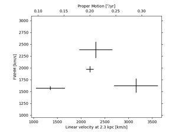

[Parasite Simple2](https://matplotlib.org/stable/gallery/axes_grid1/parasite_simple2.html)

Parasite Simple2

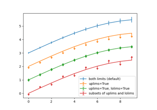

[Errorbar limit selection](https://matplotlib.org/stable/gallery/lines_bars_and_markers/errorbar_limits_simple.html)

Errorbar limit selection

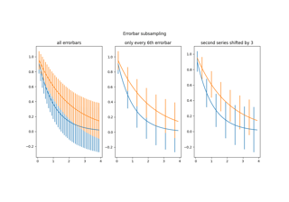

[Errorbar subsampling](https://matplotlib.org/stable/gallery/lines_bars_and_markers/errorbar_subsample.html)

Errorbar subsampling

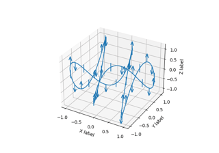

[3D errorbars](https://matplotlib.org/stable/gallery/mplot3d/errorbar3d.html)

3D errorbars

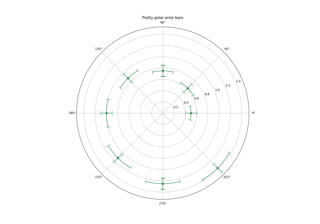

[Error bar rendering on polar axis](https://matplotlib.org/stable/gallery/pie_and_polar_charts/polar_error_caps.html)

Error bar rendering on polar axis

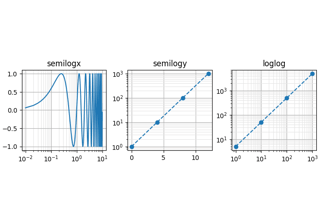

[Log scale](https://matplotlib.org/stable/gallery/scales/log_demo.html)

Log scale

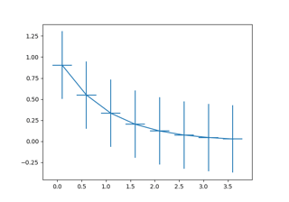

[Errorbar function](https://matplotlib.org/stable/gallery/statistics/errorbar.html)

Errorbar function

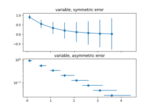

[Different ways of specifying error bars](https://matplotlib.org/stable/gallery/statistics/errorbar_features.html)

Different ways of specifying error bars

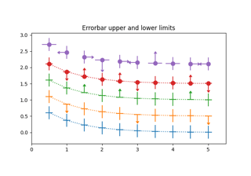

[Including upper and lower limits in error bars](https://matplotlib.org/stable/gallery/statistics/errorbar_limits.html)

Including upper and lower limits in error bars

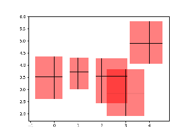

[Create boxes from error bars using PatchCollection](https://matplotlib.org/stable/gallery/statistics/errorbars_and_boxes.html)

Create boxes from error bars using PatchCollection

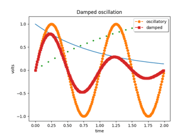

[Legend Demo](https://matplotlib.org/stable/gallery/text_labels_and_annotations/legend_demo.html)

Legend Demo

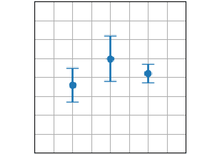

[errorbar(x, y, yerr, xerr)](https://matplotlib.org/stable/plot_types/stats/errorbar_plot.html)

errorbar(x, y, yerr, xerr)